# ECON 487 Lab 4

Rohan Narasayya

2023-10-22

```r
library(ggplot2)
library(glmnet)
library(stringr)
library(dplyr)
oj <- read.csv("oj.csv")
oj_reg_demo <- oj %>%
  mutate(id_val = row_number(), # we're going to create an ID variable to separate train and test later
         log_price = log(price))
lagged_df <- oj_reg_demo %>%
  arrange(week) %>% # sort the data by week
  group_by(store, brand) %>% # only lag within a store and brand
  mutate(lag_price = ifelse(lag(week) + 1 == week, lag(log_price), NA)) %>% # calculate lagged prices only if subsequent weeks
  ungroup() %>% filter(!is.na(lag_price))

# to double check, you can inspect the data sorted by the relevant variables
lagged_df %>%
  arrange(store, brand, week) %>%
  select(store, brand, week, log_price, lag_price) %>%
  head(10)
```

```
## # A tibble: 10 × 5
##    store brand      week log_price lag_price
##    <int> <chr>     <int>     <dbl>     <dbl>
##  1     2 dominicks    47     0.737     0.990
##  2     2 dominicks    48     0.737     0.737
##  3     2 dominicks    51     0.637     0.737
##  4     2 dominicks    52     0.637     0.637
##  5     2 dominicks    53     0.637     0.637
##  6     2 dominicks    54     0.582     0.637
##  7     2 dominicks    58     0.215     0.990
##  8     2 dominicks    59     0.464     0.215
##  9     2 dominicks    60     0.464     0.464
## 10     2 dominicks    61     0.255     0.464
```

```r
head(lagged_df)
```

```
## # A tibble: 6 × 20
##   store brand        week logmove  feat price AGE60   EDUC ETHNIC INCOME HHLARGE
##   <int> <chr>       <int>   <dbl> <int> <dbl> <dbl>  <dbl>  <dbl>  <dbl>   <dbl>
## 1     8 tropicana      41    8.90     0  3.19 0.252 0.0952 0.0352   10.6  0.132
## 2     8 minute.maid    41   10.9      1  1.99 0.252 0.0952 0.0352   10.6  0.132
## 3     8 dominicks      41    8.76     0  2.29 0.252 0.0952 0.0352   10.6  0.132
## 4     9 tropicana      41    9.08     0  3.19 0.269 0.222  0.0326   10.8  0.0968
## 5     9 minute.maid    41   11.2      1  1.99 0.269 0.222  0.0326   10.8  0.0968
## 6     9 dominicks      41    7.05     0  2.29 0.269 0.222  0.0326   10.8  0.0968
## # … with 9 more variables: WORKWOM <dbl>, HVAL150 <dbl>, SSTRDIST <dbl>,
## #   SSTRVOL <dbl>, CPDIST5 <dbl>, CPWVOL5 <dbl>, id_val <int>, log_price <dbl>,
## #   lag_price <dbl>
```

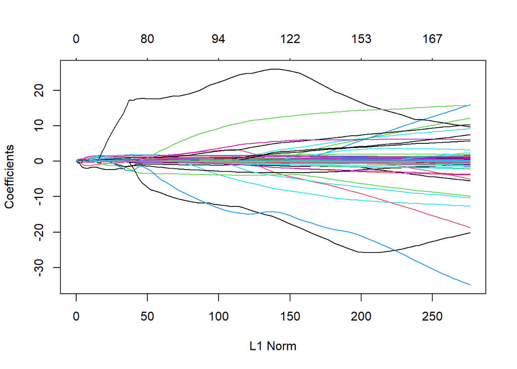

```r
set.seed(720)

formula = str_c(
  'logmove ~ (log(price) + brand + ',
  str_c(colnames(lagged_df)[c(5:20)], collapse = ' + '),
  ')^2'
)

model <- lm(formula=formula, data = lagged_df)

# we want to run LASSO

X_mat <- model.matrix(model)
lasso <- glmnet(x=X_mat, y=lagged_df$logmove, alpha = 1)
plot(lasso)
```

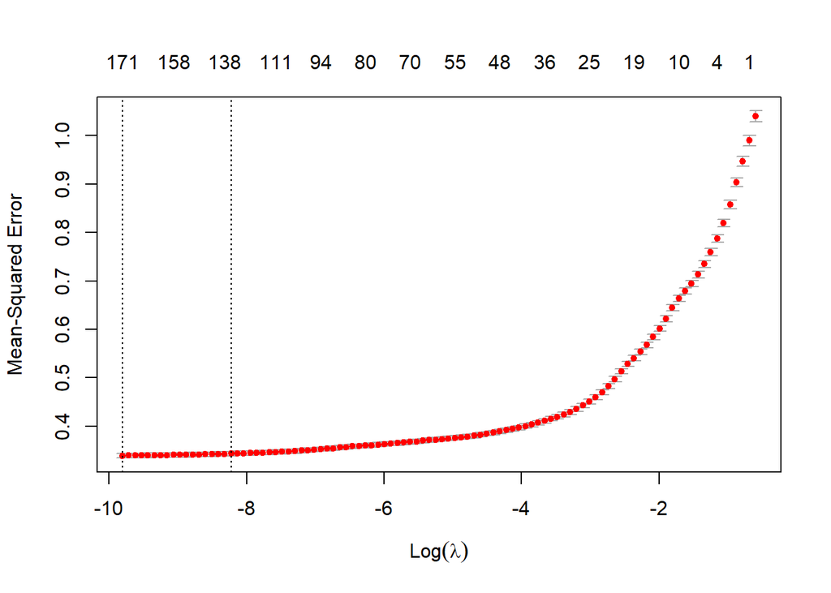

```r
# need to cross validate
lass_cv <- cv.glmnet(x=X_mat, y=lagged_df$logmove, alpha = 1)

plot(lass_cv)
```

```r
coef(lass_cv, s=lass_cv$lambda.min)
```

```
## 191 x 1 sparse Matrix of class "dgCMatrix"
##                                        s1
## (Intercept)                  7.704586e+00
## (Intercept)                  .
## log(price)                  -4.949686e-01
## brandminute.maid            -1.122252e+00
## brandtropicana               1.907407e-01
## feat                         9.837303e-01
## price                        .
## AGE60                        9.210759e+00
## EDUC                        -1.486264e+00
## ETHNIC                       5.459718e-01
## INCOME                       1.318927e-03
## HHLARGE                      1.216295e+01
## WORKWOM                      1.250758e-01
## HVAL150                      .
## SSTRDIST                     2.899232e-05
## SSTRVOL                      7.109182e-01
## CPDIST5                     -5.377156e-01
## CPWVOL5                     -1.043077e+00
## id_val                       .
## log_price                   -3.144065e-02
## lag_price                    1.214227e+00
## log(price):brandminute.maid -7.571517e-01
## log(price):brandtropicana    3.710025e-01
## log(price):feat              6.254853e-02
## log(price):price             2.442835e-01
## log(price):AGE60            -8.990139e-02
## log(price):EDUC             -5.570684e-01
## log(price):ETHNIC           -4.473190e-01
## log(price):INCOME           -3.754513e-03
## log(price):HHLARGE          -5.469957e+00
## log(price):WORKWOM           6.797834e-01
## log(price):HVAL150           .
## log(price):SSTRDIST          .
## log(price):SSTRVOL          -6.349244e-02
## log(price):CPDIST5           6.300729e-02
## log(price):CPWVOL5           .
## log(price):id_val            6.717018e-06
## log(price):log_price        -3.881919e+00
```

[output cut: 138 more lines]

```
## SSTRVOL:CPDIST5             -1.650721e-01
## SSTRVOL:CPWVOL5             -2.679055e-01
## SSTRVOL:id_val               2.863077e-06
## SSTRVOL:log_price           -5.139408e-03
## SSTRVOL:lag_price            3.084660e-02
## CPDIST5:CPWVOL5             -2.927220e-01
## CPDIST5:id_val               1.383620e-06
## CPDIST5:log_price           -1.257454e-03
## CPDIST5:lag_price            3.193860e-02
## CPWVOL5:id_val              -4.960430e-05
## CPWVOL5:log_price            .
## CPWVOL5:lag_price           -6.262096e-02
## id_val:log_price             1.796070e-08
## id_val:lag_price             2.524382e-06
## log_price:lag_price          2.220659e-03
```

```r
mean(lass_cv$cvm)
```

```
## [1] 0.4480536
```

The advantage of using Lasso is we get to try a large number of features and interactions and we get to empirically see which features and interactions are most important and also unimportant. There is no way we could figure this out using economic intuition alone. We got to use economic intuition when we decided what features we wanted Lasso to use. We could have provided more or less features depending on what features we thought could be strong predictors of quantity.

We will run the regression model, but kick out WORKWOM, HVAL150, and SSTRDIST.

```r
temp <- lagged_df
# remove the three columns we don't want
temp <- temp %>% select(-(WORKWOM:SSTRDIST))
formula = str_c(
  'logmove ~ (log(price) + brand + ',
  str_c(colnames(temp)[c(5:17)], collapse = ' + '),
  ')^2'
)

model <- lm(formula=formula, data = temp)
summary(model)
```

```
##
## Call:
## lm(formula = formula, data = temp)
##
## Residuals:
##     Min      1Q  Median      3Q     Max
## -4.9149 -0.3315 -0.0144  0.3145  3.0795
##
## Coefficients: (15 not defined because of singularities)
##                               Estimate Std. Error t value Pr(>|t|)
## (Intercept)                  1.133e+02  1.332e+01   8.508  < 2e-16 ***
## log(price)                   7.108e+01  1.124e+01   6.326 2.56e-10 ***
## brandminute.maid            -2.226e+00  9.159e-01  -2.430 0.015090 *
## brandtropicana               3.621e+00  1.187e+00   3.051 0.002285 **
## feat                        -7.880e-01  7.906e-01  -0.997 0.318900
## price                       -1.075e+02  1.280e+01  -8.398  < 2e-16 ***
## AGE60                        5.668e+01  9.539e+00   5.943 2.84e-09 ***
## EDUC                         1.078e+01  3.068e+00   3.513 0.000443 ***
## ETHNIC                       3.095e+00  2.212e+00   1.399 0.161812
## INCOME                      -8.970e-02  4.720e-01  -0.190 0.849283
## HHLARGE                      1.246e+02  2.776e+01   4.486 7.27e-06 ***
## SSTRVOL                      9.745e+00  1.064e+00   9.160  < 2e-16 ***
## CPDIST5                     -7.032e+00  7.552e-01  -9.311  < 2e-16 ***
## CPWVOL5                     -2.475e+01  3.787e+00  -6.536 6.43e-11 ***
## id_val                      -2.858e-04  8.181e-05  -3.493 0.000478 ***
## log_price                           NA         NA      NA       NA
## lag_price                    3.083e+00  1.553e+00   1.985 0.047143 *
## log(price):brandminute.maid -1.558e+00  4.715e-01  -3.304 0.000955 ***
## log(price):brandtropicana    4.912e+00  7.907e-01   6.213 5.29e-10 ***
## log(price):feat             -1.638e+00  2.684e-01  -6.101 1.07e-09 ***
## log(price):price             3.312e+01  3.388e+00   9.776  < 2e-16 ***
## log(price):AGE60            -4.194e+00  1.639e+00  -2.559 0.010492 *
## log(price):EDUC             -3.112e+00  1.458e+00  -2.135 0.032781 *
## log(price):ETHNIC           -1.968e-01  6.868e-01  -0.287 0.774415
## log(price):INCOME            3.654e-01  6.473e-01   0.564 0.572444
## log(price):HHLARGE          -1.783e+01  3.828e+00  -4.659 3.20e-06 ***
## log(price):SSTRVOL          -5.094e-03  1.859e-01  -0.027 0.978143
## log(price):CPDIST5          -7.897e-02  1.310e-01  -0.603 0.546765
## log(price):CPWVOL5          -2.368e-01  4.936e-01  -0.480 0.631381
## log(price):id_val            3.445e-05  1.077e-05   3.199 0.001382 **
```

[output cut: 97 more lines]

```
## CPDIST5:id_val              -6.407e-06  1.216e-06  -5.270 1.37e-07 ***
## CPDIST5:log_price                   NA         NA      NA       NA
## CPDIST5:lag_price           -4.534e-03  3.294e-02  -0.138 0.890513
## CPWVOL5:id_val              -2.259e-05  4.436e-06  -5.094 3.53e-07 ***
## CPWVOL5:log_price                   NA         NA      NA       NA
## CPWVOL5:lag_price           -5.531e-02  1.206e-01  -0.459 0.646491
## id_val:log_price                    NA         NA      NA       NA
## id_val:lag_price             1.846e-06  2.615e-06   0.706 0.480224
## log_price:lag_price                 NA         NA      NA       NA
## ---
## Signif. codes:  0 '***' 0.001 '**' 0.01 '*' 0.05 '.' 0.1 ' ' 1
##
## Residual standard error: 0.5938 on 27887 degrees of freedom
## Multiple R-squared:  0.6627, Adjusted R-squared:  0.6612
## F-statistic: 456.5 on 120 and 27887 DF,  p-value: < 2.2e-16
```

The coefficient of lag price is 3.083, and the corresponding elasticity is 19.32 + 3.083 = 22.403. For tropicana, the elasticity is 22.941 and it is 18.44 when it is featured. The 95 % confidence interval is the estimated value +- 1.96 * standard error. The 95% confidence interval is 22.941 +- 1.96 * 1.187 = (20.61, 25.27). According to the data, Dominicks has an elasticity of 19.32, minute maid has an elasticity of 17.094, and Tropicana has an elasticity of 22.941.

Products with high elasticity of demand are more sensitive to changes in price and have a higher price elasticity of demand than products with low elasticity of demand 2. Therefore, products with high elasticity of demand should have a lower markup over costs than products with low elasticity of demand because a higher markup over costs would lead to a higher price and a decrease in demand.

```r
# Subset the data for Dominicks
dominicks_data <- oj[oj$brand == "dominicks", ]
minute_data <- oj[oj$brand == "minute.maid", ]
tropicana_data <- oj[oj$brand == "tropicana", ]
cross_matrix <- matrix(, nrow=3, ncol=3)

dominicks_model <- lm(logmove ~ log(price) + AGE60 + EDUC + ETHNIC + INCOME + HHLARGE + WORKWOM + HVAL150 + SSTRDIST + SSTRVOL + CPDIST5 + CPWVOL5, data = dominicks_data)
dominicks_coef <- coef(dominicks_model)
cross_matrix[1,1] <- dominicks_coef["log(price)"]

minute_from_dom_model <- lm(minute_data$logmove ~ log(price) + AGE60 + EDUC + ETHNIC + INCOME + HHLARGE + WORKWOM + HVAL150 + SSTRDIST + SSTRVOL + CPDIST5 + CPWVOL5, data = dominicks_data)
minute_coef <- coef(minute_from_dom_model)
cross_matrix[1,2] <- minute_coef["log(price)"]

trop_from_dom_model <- lm(tropicana_data$logmove ~ log(price) + AGE60 + EDUC + ETHNIC + INCOME + HHLARGE + WORKWOM + HVAL150 + SSTRDIST + SSTRVOL + CPDIST5 + CPWVOL5, data = dominicks_data)
trop_coef <- coef(trop_from_dom_model)
cross_matrix[1,3] <- trop_coef["log(price)"]

dom_from_minute_model <- lm(dominicks_data$logmove ~ log(price) + AGE60 + EDUC + ETHNIC + INCOME + HHLARGE + WORKWOM + HVAL150 + SSTRDIST + SSTRVOL + CPDIST5 + CPWVOL5, data = minute_data)
dom_from_minute_coef <- coef(dom_from_minute_model)
cross_matrix[2,1] <- dom_from_minute_coef["log(price)"]

minute_model <- lm(logmove ~ log(price) + AGE60 + EDUC + ETHNIC + INCOME + HHLARGE + WORKWOM + HVAL150 + SSTRDIST + SSTRVOL + CPDIST5 + CPWVOL5, data = minute_data)
minute_coef <- coef(minute_model)
cross_matrix[2,2] <- minute_coef["log(price)"]

trop_from_minute_model <- lm(tropicana_data$logmove ~ log(price) + AGE60 + EDUC + ETHNIC + INCOME + HHLARGE + WORKWOM + HVAL150 + SSTRDIST + SSTRVOL + CPDIST5 + CPWVOL5, data = minute_data)
trop_coef <- coef(trop_from_minute_model)
cross_matrix[2,3] <- trop_coef["log(price)"]

dom_from_trop_model <- lm(dominicks_data$logmove ~ log(price) + AGE60 + EDUC + ETHNIC + INCOME + HHLARGE + WORKWOM + HVAL150 + SSTRDIST + SSTRVOL + CPDIST5 + CPWVOL5, data = tropicana_data)
dom_coef <- coef(dom_from_trop_model)
cross_matrix[3,1] <- dom_coef["log(price)"]

minute_from_trop_model <- lm(minute_data$logmove ~ log(price) + AGE60 + EDUC + ETHNIC + INCOME + HHLARGE + WORKWOM + HVAL150 + SSTRDIST + SSTRVOL + CPDIST5 + CPWVOL5, data = tropicana_data)
minute_coef <- coef(minute_from_trop_model)
cross_matrix[3,2] <- minute_coef["log(price)"]

trop_model <- lm(logmove ~ log(price) + AGE60 + EDUC + ETHNIC + INCOME + HHLARGE + WORKWOM + HVAL150 + SSTRDIST + SSTRVOL + CPDIST5 + CPWVOL5, data = tropicana_data)
trop_coef <- coef(trop_model)
cross_matrix[3,3] <- trop_coef["log(price)"]
cross_matrix
```

```
##            [,1]       [,2]       [,3]
## [1,] -3.3898642  0.5284768 -0.1486382
## [2,]  0.5843462 -3.4564704 -0.4798158
## [3,] -0.2309484  0.3745788 -2.8714104
```

```r
cross_matrix_int <- matrix(, nrow=3, ncol=3)

dominicks_model <- lm(logmove ~ log(price) + feat + AGE60 + EDUC + ETHNIC + INCOME + HHLARGE + WORKWOM + HVAL150 + SSTRDIST + SSTRVOL + CPDIST5 + CPWVOL5, data = dominicks_data)
dominicks_coef <- coef(dominicks_model)
cross_matrix_int[1,1] <- dominicks_coef["log(price)"]

minute_from_dom_model <- lm(minute_data$logmove ~ log(price) + feat + AGE60 + EDUC + ETHNIC + INCOME + HHLARGE + WORKWOM + HVAL150 + SSTRDIST + SSTRVOL + CPDIST5 + CPWVOL5, data = dominicks_data)
minute_coef <- coef(minute_from_dom_model)
cross_matrix_int[1,2] <- minute_coef["log(price)"]

trop_from_dom_model <- lm(tropicana_data$logmove ~ log(price) + feat + AGE60 + EDUC + ETHNIC + INCOME + HHLARGE + WORKWOM + HVAL150 + SSTRDIST + SSTRVOL + CPDIST5 + CPWVOL5, data = dominicks_data)
trop_coef <- coef(trop_from_dom_model)
cross_matrix_int[1,3] <- trop_coef["log(price)"]

dom_from_minute_model <- lm(dominicks_data$logmove ~ log(price) + feat + AGE60 + EDUC + ETHNIC + INCOME + HHLARGE + WORKWOM + HVAL150 + SSTRDIST + SSTRVOL + CPDIST5 + CPWVOL5, data = minute_data)
dom_from_minute_coef <- coef(dom_from_minute_model)
cross_matrix_int[2,1] <- dom_from_minute_coef["log(price)"]

minute_model <- lm(logmove ~ log(price) + feat + AGE60 + EDUC + ETHNIC + INCOME + HHLARGE + WORKWOM + HVAL150 + SSTRDIST + SSTRVOL + CPDIST5 + CPWVOL5, data = minute_data)
minute_coef <- coef(minute_model)
cross_matrix_int[2,2] <- minute_coef["log(price)"]

trop_from_minute_model <- lm(tropicana_data$logmove ~ log(price) + feat + AGE60 + EDUC + ETHNIC + INCOME + HHLARGE + WORKWOM + HVAL150 + SSTRDIST + SSTRVOL + CPDIST5 + CPWVOL5, data = minute_data)
trop_coef <- coef(trop_from_minute_model)
cross_matrix_int[2,3] <- trop_coef["log(price)"]

dom_from_trop_model <- lm(dominicks_data$logmove ~ log(price) + feat + AGE60 + EDUC + ETHNIC + INCOME + HHLARGE + WORKWOM + HVAL150 + SSTRDIST + SSTRVOL + CPDIST5 + CPWVOL5, data = tropicana_data)
dom_coef <- coef(dom_from_trop_model)
cross_matrix_int[3,1] <- dom_coef["log(price)"]

minute_from_trop_model <- lm(minute_data$logmove ~ log(price) + feat + AGE60 + EDUC + ETHNIC + INCOME + HHLARGE + WORKWOM + HVAL150 + SSTRDIST + SSTRVOL + CPDIST5 + CPWVOL5, data = tropicana_data)
minute_coef <- coef(minute_from_trop_model)
cross_matrix_int[3,2] <- minute_coef["log(price)"]

trop_model <- lm(logmove ~ log(price) + feat + AGE60 + EDUC + ETHNIC + INCOME + HHLARGE + WORKWOM + HVAL150 + SSTRDIST + SSTRVOL + CPDIST5 + CPWVOL5, data = tropicana_data)
trop_coef <- coef(trop_model)
cross_matrix_int[3,3] <- trop_coef["log(price)"]
```

```r
cross_matrix
```

```
##            [,1]       [,2]       [,3]
## [1,] -3.3898642  0.5284768 -0.1486382
## [2,]  0.5843462 -3.4564704 -0.4798158
## [3,] -0.2309484  0.3745788 -2.8714104
```

```r
cross_matrix_int
```

```
##            [,1]       [,2]       [,3]
## [1,] -2.9082443  0.3743561 -0.1987893
## [2,]  0.2546485 -2.4872049 -0.8882533
## [3,] -0.4789341  0.1009907 -2.4716573
```

The own price diagonal entries decrease in absolute value in the interaction matrix. We can see three of the cross price values get smaller in absolute value, but three also get larger. When minute maid is feature and it lowers its price, Tropicana suffers the most in terms of sales. Dominicks and Minute Maid are the most competitive because they have the highest cross price values in the cross_matrix. This is because a change in the price of one brand has the largest impact on quantity of the other brand. If two products are highly competitive, we would expect their prices to be highly correlated, because changes in one product’s price would lead to changes in the other product’s price.

```r
oj$Q <- exp(oj$logmove)
library(plyr)
library(tidyr)
Df1 <- ddply(oj, c('store','week'),function(oj) c(weighted_mean = weighted.mean(oj$price,oj$Q)))
oj <- merge(oj, Df1)
oj_wide <- oj %>%
  pivot_wider(names_from = brand, values_from = price)
```

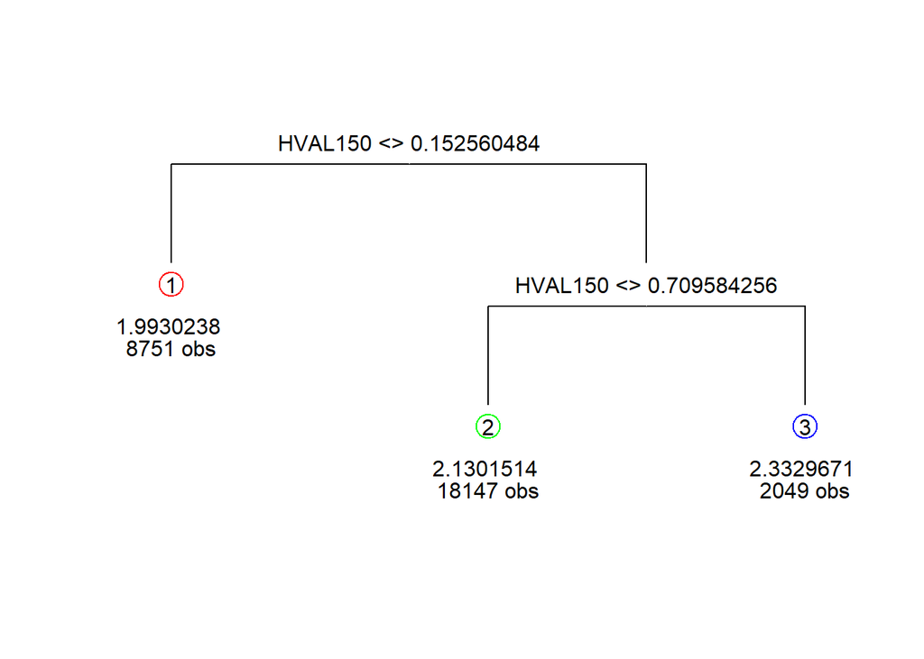

```r
library(rpart)
library(rpart.plot)
library(partykit)
library(permute)
library(maptree)
dataToPass<-oj[,c("weighted_mean","AGE60","EDUC","ETHNIC","INCOME","HHLARGE","WORKWOM","HVAL150","SSTRDIST","SSTRVOL","CPDIST5","CPWVOL5")]
fit<-rpart(as.formula(weighted_mean ~ .),data=dataToPass,method="anova",cp=0.007)
draw.tree(fit)
```

```r
dataToPass$leaf = fit$where
oj_leaf_2 <- subset(oj, dataToPass$leaf == 2)
oj_leaf_4 <- subset(oj, dataToPass$leaf == 4)
oj_leaf_5 <- subset(oj, dataToPass$leaf == 5)
reg_int_2 <- glm(logmove~log(price)*brand*feat, data=oj_leaf_2)
summary(reg_int_2)
```

```
##
## Call:
## glm(formula = logmove ~ log(price) * brand * feat, data = oj_leaf_2)
##
## Deviance Residuals:
##     Min       1Q   Median       3Q      Max
## -5.1776  -0.4516   0.0092   0.4288   3.1820
##
## Coefficients:
##                                  Estimate Std. Error t value Pr(>|t|)
## (Intercept)                      10.69432    0.04438 240.984  < 2e-16 ***
## log(price)                       -2.83435    0.07628 -37.158  < 2e-16 ***
## brandminute.maid                  0.07093    0.08715   0.814 0.415768
## brandtropicana                    0.80881    0.09827   8.231  < 2e-16 ***
## feat                              1.15089    0.07148  16.101  < 2e-16 ***
## log(price):brandminute.maid       0.35607    0.11898   2.993 0.002773 **
## log(price):brandtropicana         0.13414    0.11231   1.194 0.232340
## log(price):feat                  -0.55800    0.14168  -3.939 8.26e-05 ***
## brandminute.maid:feat             1.02950    0.15135   6.802 1.10e-11 ***
## brandtropicana:feat               0.61614    0.18853   3.268 0.001087 **
## log(price):brandminute.maid:feat -0.82352    0.23008  -3.579 0.000346 ***
## log(price):brandtropicana:feat   -0.83239    0.23962  -3.474 0.000516 ***
## ---
## Signif. codes:  0 '***' 0.001 '**' 0.01 '*' 0.05 '.' 0.1 ' ' 1
##
## (Dispersion parameter for gaussian family taken to be 0.5127612)
##
##     Null deviance: 10534  on 8750  degrees of freedom
## Residual deviance:  4481  on 8739  degrees of freedom
## AIC: 19003
##
## Number of Fisher Scoring iterations: 2
```

```r
reg_int_4 <- glm(logmove~log(price)*brand*feat, data=oj_leaf_4)
summary(reg_int_4)
```

```
##
## Call:
## glm(formula = logmove ~ log(price) * brand * feat, data = oj_leaf_4)
##
## Deviance Residuals:
##     Min       1Q   Median       3Q      Max
## -4.5121  -0.3951  -0.0186   0.3765   3.1672
##
## Coefficients:
##                                  Estimate Std. Error t value Pr(>|t|)
## (Intercept)                      10.22400    0.02762 370.107  < 2e-16 ***
## log(price)                       -2.61130    0.04580 -57.013  < 2e-16 ***
## brandminute.maid                  0.13936    0.05531   2.519   0.0118 *
## brandtropicana                    0.90413    0.05951  15.194  < 2e-16 ***
## feat                              1.12525    0.04492  25.048  < 2e-16 ***
## log(price):brandminute.maid       0.71909    0.07239   9.934  < 2e-16 ***
## log(price):brandtropicana         0.61339    0.06655   9.218  < 2e-16 ***
## log(price):feat                  -0.52602    0.08700  -6.047 1.51e-09 ***
## brandminute.maid:feat             1.12910    0.09712  11.626  < 2e-16 ***
## brandtropicana:feat               0.67774    0.11549   5.869 4.47e-09 ***
## log(price):brandminute.maid:feat -1.05273    0.14416  -7.302 2.95e-13 ***
## log(price):brandtropicana:feat   -0.86642    0.14483  -5.982 2.24e-09 ***
## ---
## Signif. codes:  0 '***' 0.001 '**' 0.01 '*' 0.05 '.' 0.1 ' ' 1
##
## (Dispersion parameter for gaussian family taken to be 0.4138273)
##
##     Null deviance: 17027.1  on 18146  degrees of freedom
## Residual deviance:  7504.8  on 18135  degrees of freedom
## AIC: 35502
##
## Number of Fisher Scoring iterations: 2
```

```r
reg_int_5 <- glm(logmove~log(price)*brand*feat, data=oj_leaf_5)
summary(reg_int_5)
```

```
##
## Call:
## glm(formula = logmove ~ log(price) * brand * feat, data = oj_leaf_5)
##
## Deviance Residuals:
##     Min       1Q   Median       3Q      Max
## -3.8545  -0.3337  -0.0259   0.3459   2.6984
##
## Coefficients:
##                                  Estimate Std. Error t value Pr(>|t|)
## (Intercept)                      10.28239    0.07301 140.840  < 2e-16 ***
## log(price)                       -3.04115    0.10983 -27.689  < 2e-16 ***
## brandminute.maid                  0.45944    0.15542   2.956 0.003150 **
## brandtropicana                    1.55767    0.16245   9.589  < 2e-16 ***
## feat                              0.95944    0.12432   7.718 1.84e-14 ***
## log(price):brandminute.maid       1.18514    0.18756   6.319 3.23e-10 ***
## log(price):brandtropicana         1.07617    0.16803   6.405 1.87e-10 ***
## log(price):feat                  -0.22146    0.23132  -0.957 0.338511
## brandminute.maid:feat             0.95715    0.27417   3.491 0.000491 ***
## brandtropicana:feat               0.22279    0.32122   0.694 0.488024
## log(price):brandminute.maid:feat -1.14273    0.39337  -2.905 0.003712 **
## log(price):brandtropicana:feat   -0.54092    0.39204  -1.380 0.167813
## ---
## Signif. codes:  0 '***' 0.001 '**' 0.01 '*' 0.05 '.' 0.1 ' ' 1
##
## (Dispersion parameter for gaussian family taken to be 0.3974853)
##
##     Null deviance: 2427.93  on 2048  degrees of freedom
## Residual deviance:  809.68  on 2037  degrees of freedom
## AIC: 3938.4
##
## Number of Fisher Scoring iterations: 2
```

```r
head(oj_leaf_2)
```

```
##   store week       brand   logmove feat price     AGE60       EDUC    ETHNIC
## 1   100  100 minute.maid  8.515592    0  2.39 0.1369951 0.04955029 0.5640868
## 2   100  100   dominicks  9.547955    0  1.32 0.1369951 0.04955029 0.5640868
## 3   100  100   tropicana  8.921057    0  2.50 0.1369951 0.04955029 0.5640868
## 4   100  101   tropicana  8.589700    0  3.59 0.1369951 0.04955029 0.5640868
## 5   100  101 minute.maid  9.486759    0  1.66 0.1369951 0.04955029 0.5640868
## 6   100  101   dominicks 10.888707    1  1.49 0.1369951 0.04955029 0.5640868
##     INCOME   HHLARGE  WORKWOM    HVAL150 SSTRDIST  SSTRVOL  CPDIST5  CPWVOL5
## 1 10.03658 0.2163543 0.267234 0.01111797 8.369535 1.115385 2.109824 0.197684
## 2 10.03658 0.2163543 0.267234 0.01111797 8.369535 1.115385 2.109824 0.197684
## 3 10.03658 0.2163543 0.267234 0.01111797 8.369535 1.115385 2.109824 0.197684
## 4 10.03658 0.2163543 0.267234 0.01111797 8.369535 1.115385 2.109824 0.197684
## 5 10.03658 0.2163543 0.267234 0.01111797 8.369535 1.115385 2.109824 0.197684
## 6 10.03658 0.2163543 0.267234 0.01111797 8.369535 1.115385 2.109824 0.197684
##       Q weighted_mean
## 1  4992      1.855072
## 2 14016      1.855072
## 3  7488      1.855072
## 4  5376      1.677595
## 5 13184      1.677595
## 6 53568      1.677595
```

```r
wide_data <- oj_reg_demo %>%
  select(store, week, brand, log_price) %>%
  pivot_wider(
    id_cols = c(store, week),
    names_from = brand,
    values_from=log_price
  )
cross_price_data <- oj_reg_demo %>%
  select(store, week, logmove, brand) %>%
  left_join(wide_data,
            by = c('store', 'week'))

oj_leaf_2 <- merge(oj_leaf_2, cross_price_data)

cross_matrix_2 <- matrix(, nrow=3, ncol=3)
oj_leaf_2_D <- subset(oj_leaf_2, oj_leaf_2$brand == "dominicks")
oj_leaf_2_M <- subset(oj_leaf_2, oj_leaf_2$brand == "minute.maid")
oj_leaf_2_T <- subset(oj_leaf_2, oj_leaf_2$brand == "tropicana")
reg_int_2_D <- glm(logmove~log(price):feat + minute.maid:feat + tropicana:feat, data=oj_leaf_2_D)
reg_int_2_M <- glm(logmove~log(price):feat + tropicana:feat + dominicks:feat, data=oj_leaf_2_D)
reg_int_2_T <- glm(logmove~log(price):feat + dominicks:feat + minute.maid:feat, data=oj_leaf_2_D)
cross_matrix_2[1,1] <- coef(reg_int_2_D)["log(price):feat"]
cross_matrix_2[1,2] <- coef(reg_int_2_D)["feat:minute.maid"]
cross_matrix_2[1,3] <- coef(reg_int_2_D)["feat:tropicana"]
cross_matrix_2[2,1] <- coef(reg_int_2_M)["feat:dominicks"]
cross_matrix_2[2,2] <- coef(reg_int_2_M)["log(price):feat"]
cross_matrix_2[2,3] <- coef(reg_int_2_M)["feat:tropicana"]
cross_matrix_2[3,1] <- coef(reg_int_2_T)["feat:dominicks"]
cross_matrix_2[3,2] <- coef(reg_int_2_T)["feat:minute.maid"]
cross_matrix_2[3,3] <- coef(reg_int_2_T)["log(price):feat"]
cross_matrix_2
```

```
##           [,1]      [,2]       [,3]
## [1,] -3.451315  2.320175  0.8504998
## [2,]        NA -2.944278  2.3828013
## [3,]        NA  3.339868 -3.3562015
```

```r
oj_leaf_4 <- merge(oj_leaf_4, cross_price_data)

cross_matrix_4 <- matrix(, nrow=3, ncol=3)
oj_leaf_4_D <- subset(oj_leaf_4, oj_leaf_4$brand == "dominicks")
oj_leaf_4_M <- subset(oj_leaf_4, oj_leaf_4$brand == "minute.maid")
oj_leaf_4_T <- subset(oj_leaf_4, oj_leaf_4$brand == "tropicana")
reg_int_4_D <- glm(logmove~log(price):feat + minute.maid:feat + tropicana:feat, data=oj_leaf_4_D)
reg_int_4_M <- glm(logmove~log(price):feat + tropicana:feat + dominicks:feat, data=oj_leaf_4_D)
reg_int_4_T <- glm(logmove~log(price):feat + dominicks:feat + minute.maid:feat, data=oj_leaf_4_D)
cross_matrix_4[1,1] <- coef(reg_int_4_D)["log(price):feat"]
cross_matrix_4[1,2] <- coef(reg_int_4_D)["feat:minute.maid"]
cross_matrix_4[1,3] <- coef(reg_int_4_D)["feat:tropicana"]
cross_matrix_4[2,1] <- coef(reg_int_4_M)["feat:dominicks"]
cross_matrix_4[2,2] <- coef(reg_int_4_M)["log(price):feat"]
cross_matrix_4[2,3] <- coef(reg_int_4_M)["feat:tropicana"]
cross_matrix_4[3,1] <- coef(reg_int_4_T)["feat:dominicks"]
cross_matrix_4[3,2] <- coef(reg_int_4_T)["feat:minute.maid"]
cross_matrix_4[3,3] <- coef(reg_int_4_T)["log(price):feat"]
cross_matrix_4
```

```
##           [,1]      [,2]       [,3]
## [1,] -3.200693  2.190418  0.7859413
## [2,]        NA -2.700566  2.2403898
## [3,]        NA  3.119834 -3.1072943
```

```r
oj_leaf_5 <- merge(oj_leaf_5, cross_price_data)

cross_matrix_5 <- matrix(, nrow=3, ncol=3)
oj_leaf_5_D <- subset(oj_leaf_5, oj_leaf_5$brand == "dominicks")
oj_leaf_5_M <- subset(oj_leaf_5, oj_leaf_5$brand == "minute.maid")
oj_leaf_5_T <- subset(oj_leaf_5, oj_leaf_5$brand == "tropicana")
reg_int_5_D <- glm(logmove~log(price):feat + minute.maid:feat + tropicana:feat, data=oj_leaf_5_D)
reg_int_5_M <- glm(logmove~log(price):feat + tropicana:feat + dominicks:feat, data=oj_leaf_5_D)
reg_int_5_T <- glm(logmove~log(price):feat + dominicks:feat + minute.maid:feat, data=oj_leaf_5_D)
cross_matrix_5[1,1] <- coef(reg_int_5_D)["log(price):feat"]
cross_matrix_5[1,2] <- coef(reg_int_5_D)["feat:minute.maid"]
cross_matrix_5[1,3] <- coef(reg_int_5_D)["feat:tropicana"]
cross_matrix_5[2,1] <- coef(reg_int_5_M)["feat:dominicks"]
cross_matrix_5[2,2] <- coef(reg_int_5_M)["log(price):feat"]
cross_matrix_5[2,3] <- coef(reg_int_5_M)["feat:tropicana"]
cross_matrix_5[3,1] <- coef(reg_int_5_T)["feat:dominicks"]
cross_matrix_5[3,2] <- coef(reg_int_5_T)["feat:minute.maid"]
cross_matrix_5[3,3] <- coef(reg_int_5_T)["log(price):feat"]
cross_matrix_5
```

```
##           [,1]      [,2]       [,3]
## [1,] -2.958229  2.105961  0.7675553
## [2,]        NA -2.460117  2.1830402
## [3,]        NA  2.996904 -2.8693986
```

I’m not entirely sure why the bottom two values in the first columns are null for the three matrices, but we can see that leaf 2 has the largest absolute elasticities, leaf 4 has the next largest absolute elasticites, and leaf 5 has the smallest absolute elasticities. This trend holds for every entry in the matrices.

7. In the leaf with the highest own-price elasticities, the markups should be lower relative to the other leaves. This is because a high own-price elasticity means that demand is very sensitive to price changes. Therefore, a small increase in price could lead to a large decrease in quantity demanded, which would not be beneficial for the store. Lower markups would keep prices more competitive and maintain demand.

Cross-price elasticities can vary significantly between leaves with high and low own-price elasticities. If a leaf has high own-price elasticity but low cross-price elasticity, then the store could potentially increase markups for other brands while keeping the markup for the high elasticity brand low. This would allow the store to maximize profits by capitalizing on the inelastic demand for other brands.

If a leaf has low own-price elasticity but high cross-price elasticity, then the store would need to be more cautious with pricing strategies. Changes in the price of one brand could significantly impact the demand for other brands. In this case, maintaining similar markups across brands and avoiding drastic price changes might be a safer strategy.

In terms of timing of sales, if a store falls into a leaf with high own-price elasticity, sales should be timed when demand is expected to be high in order to maximize revenue. This could be during certain seasons, holidays, or events when consumers are more likely to purchase the product.

For stores in leaves with low own-price elasticity, timing of sales might not be as crucial since demand is less sensitive to price changes. However, if cross-price elasticity is high, stores might want to consider coordinating sales across different brands to avoid cannibalization of sales.

```r
dom <- subset(oj, brand=="dominicks")
summary(dom$INCOME)
```

```
##    Min. 1st Qu.  Median    Mean 3rd Qu.    Max.
##   9.867  10.456  10.635  10.617  10.797  11.236
```